# Lab Descriptives

David John Baker

May 18, 2018

# Lab-Wide Descriptives

Write up for lab’s descriptive statistics for ICMPC 15. Data here is already split based on the Screening.R script.

```r
# Import Data
library(data.table)
library(psych)
#--------------------------------------------------
icmpc <- fread("../data/aggregated_data/AnalysisData-Deletion.csv")
dropped <- fread("../data/aggregated_data/DropList.csv")
#--------------------------------------------------
```

## Write Up

The following is the code used to generate the first paragraph of descriptives.

```r
# Total
nrow(icmpc) + nrow(dropped)
```

```
## [1] 254
```

```r
# Dropped
dropped[Outlier == "YES", .(Outlier, OutlierReason)]
```

```
##    Outlier         OutlierReason
## 1:     YES             LOW TSPAN
## 2:     YES            LOW RAVENS
## 3:     YES            LOW RAVENS
## 4:     YES LOW RAVENS, LOW OSPAN
## 5:     YES            LOW RAVENS
## 6:     YES             LOW TSPAN
```

```r
dropped[ExcludeReason == "Self Reported Hearing Loss"]
```

```
##    subjectNo Exclude              ExcludeReason Outlier OutlierReason DROP
## 1:      1305     YES Self Reported Hearing Loss      NO          NONE  YES
## 2:       509     YES Self Reported Hearing Loss      NO          NONE  YES
## 3:       537     YES Self Reported Hearing Loss      NO          NONE  YES
## 4:       544     YES Self Reported Hearing Loss      NO          NONE  YES
## 5:       545     YES Self Reported Hearing Loss      NO          NONE  YES
## 6:       717     YES Self Reported Hearing Loss      NO          NONE  YES
## 7:       719     YES Self Reported Hearing Loss      NO          NONE  YES
## 8:       907     YES Self Reported Hearing Loss      NO          NONE  YES
```

```r
# Sample
nrow(icmpc)
```

```
## [1] 240
```

```r
describe(icmpc$goldage)
```

```
##    vars   n  mean   sd median trimmed  mad min max range skew kurtosis
## X1    1 240 19.85 3.36     19   19.27 1.48  17  50    33 5.48    38.27
##      se
## X1 0.22
```

```r
table(icmpc$ravenSex)
```

```
##
## female   male
##    149     91
```

```r
#--------------------------------------------------
```

### Sample Descriptives

Two hundred fifty-four students enrolled at Louisiana State University completed the study. We recruited students, mainly in the Department of Psychology and the School of Music. The criteria inclusion in the analysis included reporting no hearing loss, not actively taking medication that would alter cognitive performance, and individuals whose performance on any task performed greater than 3 standard deviations from the mean score of that task. Using these criteria, eight participants were not eligible due to self reporting hearing loss, and six participants were eliminated as univariate outliers due to performance on one or more of the tasks of working memory capaicity. Thus, 240 participants met the criteria for inclusion. The eligible participants were between the ages of 17 and 50 (M = 19.85, SD = 3.36; 149 females). Participants volunteered, received course credit, or were paid $15.

## Related Plots

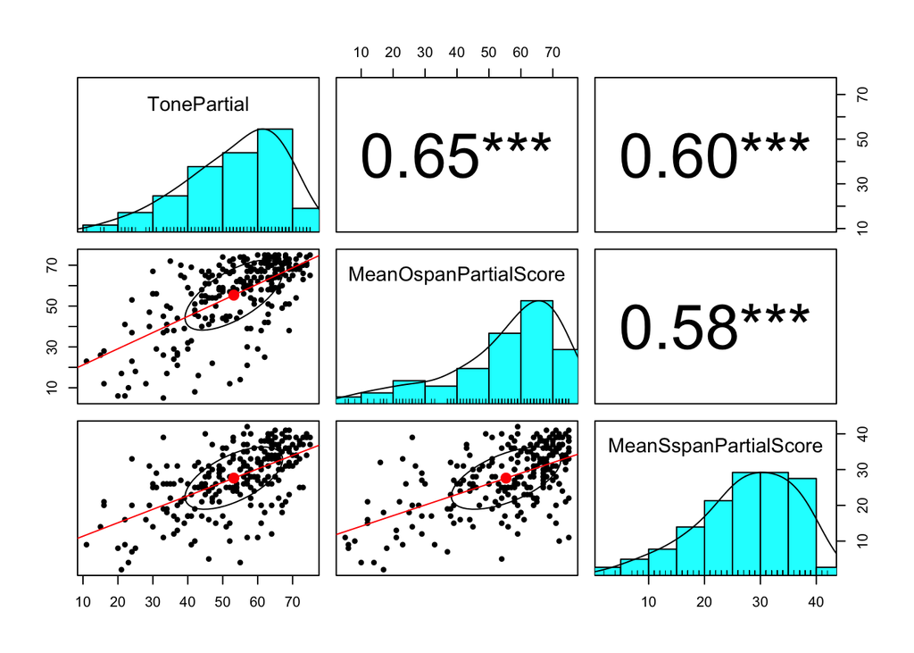

```r
#======================================================================================================
# All WMC Correlate Positive and Significant with each other
wmc <- icmpc[, .(TonePartial,
                  MeanOspanPartialScore,
                  MeanSspanPartialScore)]
pairs.panels(wmc, lm = TRUE, stars = TRUE)
```

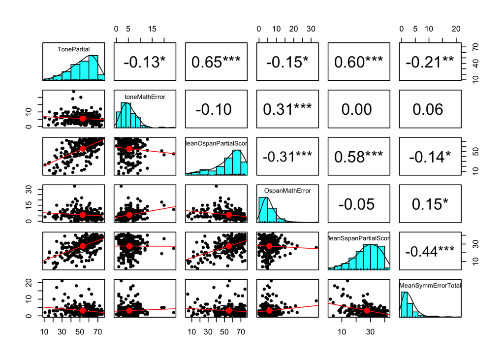

```r
# And each task should negatively correlate with own processing task
negatives <- icmpc[, .(TonePartial, toneMathError,
                        MeanOspanPartialScore, OspanMathError,
                        MeanSspanPartialScore, MeanSymmErrorTotal )]

pairs.panels(negatives, lm = TRUE, stars = TRUE)
```

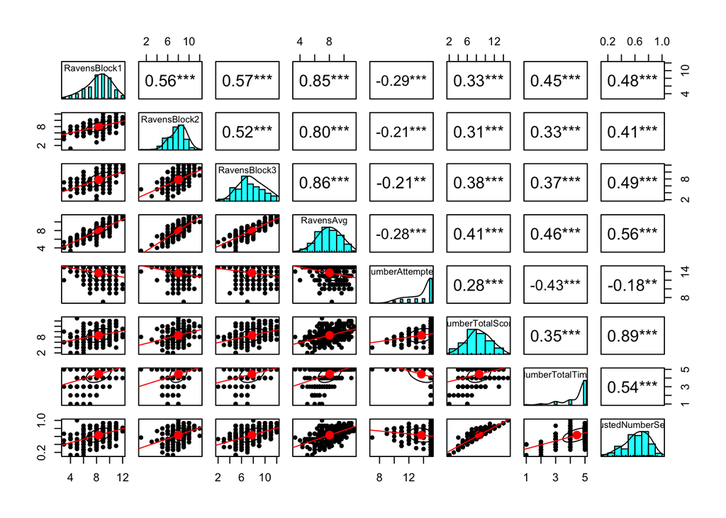

```r
#--------------------------------------------------
# Above Correlations Suggest Creating new WMC composite

icmpc[, wmc := ((scale(TonePartial)+scale(MeanOspanPartialScore)+scale(MeanSspanPartialScore))/3)]
#--------------------------------------------------
# Check that Gf are both measuring the same
# Create New Gf Variables

icmpc[, AdjustedNumberSeries := NumberTotalScore/NumberAttempted]
icmpc[, RavensAvg := RavensTotaljv/3]
gfscores <- icmpc[, .(RavensBlock1, RavensBlock2, RavensBlock3,RavensAvg, NumberAttempted, NumberTotalScore, NumberTotalTime, AdjustedNumberSeries)]

pairs.panels(gfscores, lm = TRUE, stars = TRUE)
```

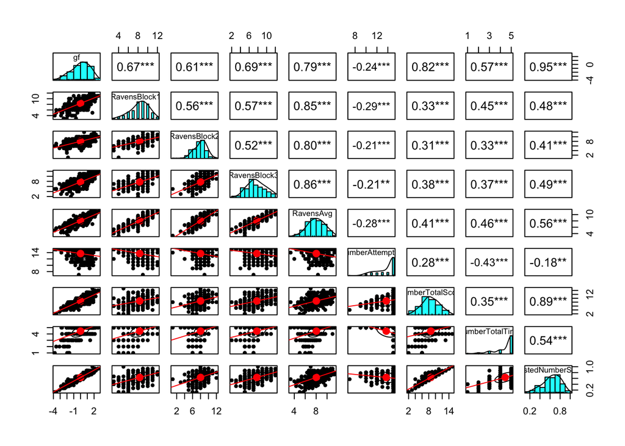

```r
#--------------------------------------------------
# Above Correlations Suggest Creating new GF composite

icmpc[, gf := (scale(AdjustedNumberSeries) + scale(RavensAvg)/2)]

gfscores <- icmpc[, .(gf,RavensBlock1, RavensBlock2, RavensBlock3,RavensAvg, NumberAttempted, NumberTotalScore, NumberTotalTime, AdjustedNumberSeries)]

pairs.panels(gfscores, lm = TRUE, stars = TRUE)
```

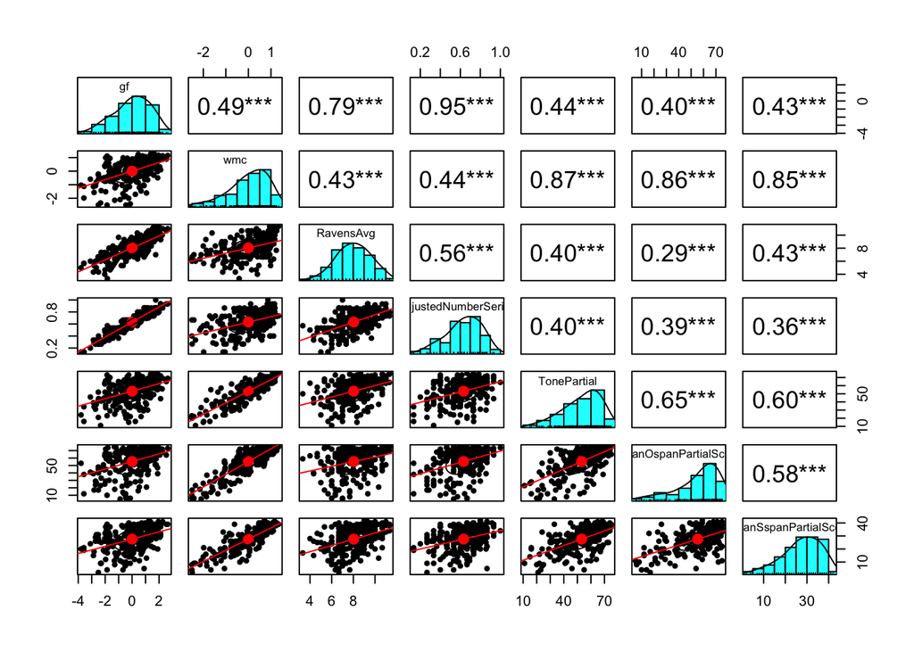

```r
#--------------------------------------------------
# Look at composites and their original scores

compositeComparer <- icmpc[, .(gf, wmc, RavensAvg, AdjustedNumberSeries, TonePartial, MeanOspanPartialScore, MeanSspanPartialScore)]

pairs.panels(compositeComparer, lm = TRUE, stars = TRUE)
```

```r
#======================================================================================================
```